# 2017-09-11-probability

> 11 Sep 2017 » probability, statistics

#### 수식이 깨질 경우 새로고침을 눌러주세요.

## Probability for Data-Science-12

## 다변수 확률 모형 ①

- **✓ Categorical (Multinoulli)**
- **✓ Multinomial**
- Dirichlet
- Multivariate Gaussian Normal

### Categorical distribution (카테고리 분포)

> 베르누이 분포의 확장판이다. Multinoulli 분포라고도 한다.

> > 베르누이 분포는 0 이나 1(또는 -1 이나 1)이 나오는 확률 변수의 분포였다.

> 카테고리 분포는 **1부터 K까지의 K개의 정수 값 중 하나가 나오는 확률 변수의 분포**이다.

> > ex) 주사위를 던져 나오는 눈금의 수 : 확률 변수 → K = 6인 카테고리 분포

> $$ 카테고리\;\; 분포의\;\; 모수\;\; \theta \;\;는\;\; 베르누이\;\; 분포와\;\; 달리\;\; 다음과\;\; 같은\;\; 제약\;\; 조건을\;\; 가지는\;\; 벡터값이\;\; 된다.$$

$$확률\;\; parameter\;\; \theta가 \;\;vector, \;\;\;\; \theta = ( \theta_1, \cdots , \theta_K ) $$$$ 0 \leq \theta_i \leq 1 $$$$ \bbox[8px, border:2px solid blue]{\sum_{i=1}^K \theta_i = 1} $$

> 정의
> - 카테고리 분포는 원래 단일 변수 확률 분포이다.
> - 하지만 일반적으로는 0 또는 1 값만 가지는 **K개 베르누이 분포 벡터를 가지는 다변수 확률 분포로 가정하여 사용**한다.
> - 다만, 이 경우 다변수 확률 변수의 각 원소 중 하나만 1이 될 수 있다는 제약 조건을 가진다.

> 이를 수식으로 나타내면 다음과 같다.

$$ X \sim \text{Cat}(x; \theta)\;\;\; 일 때, $$

$$ \begin{eqnarray} X &=& \begin{bmatrix} X = 1 \;\; (x_{1,1}=1) :\;\; \left[ 1, \;\;\;\; 0, \;\;\;\; 0, \;\;\;\;, \cdots,\;\;\;\; 0 \right] \\ X = 2 \;\; (x_{2,2}=1) :\;\; \left[ 0, \;\;\;\; 1, \;\;\;\; 0, \;\;\;\;, \cdots,\;\;\;\; 0 \right] \\ X = 3 \;\; (x_{3,3}=1) :\;\; \left[ 0, \;\;\;\; 0, \;\;\;\; 1, \;\;\;\;, \cdots,\;\;\;\; 0 \right] \\ X = i \;\; (x_{i,i}=1) :\;\; \left[ 0, \;\;\;\; 0, \;\;\;\;\; \ddots, \;\;\;\;\;\; 1,\;\;\;\; 0 \right] \\ X = k \;\; (x_{k,k}=1) :\;\; \left[ 0, \;\;\;\; 0, \;\;\;\; 0, \;\;\;\;, \cdots,\;\;\;\; 1 \right] \\ \end{bmatrix} \end{eqnarray} $$

$$ \begin{eqnarray} \text{Cat}(x;\theta) &=& \begin{bmatrix} X = 1 \;\; (x_{1,1}=1) :\;\; \left[ \theta_1^1, \;\;\;\; \theta_2^0, \;\;\;\; \theta_3^0, \;\;\;\;, \cdots,\;\;\;\; \theta_k^0 \right] \\ X = 2 \;\; (x_{2,2}=1) :\;\; \left[ \theta_1^0, \;\;\;\; \theta_2^1, \;\;\;\; \theta_3^0, \;\;\;\;, \cdots,\;\;\;\; \theta_k^0 \right] \\ X = 3 \;\; (x_{3,3}=1) :\;\; \left[ \theta_1^0, \;\;\;\; \theta_2^0, \;\;\;\; \theta_3^1, \;\;\;\;, \cdots,\;\;\;\; \theta_k^0 \right] \\ X = i \;\; (x_{i,i}=1) :\;\; \left[ \theta_1^0, \;\;\;\; \theta_2^0, \;\;\;\; \ddots, \;\;\;\; \theta_i^1,\;\;\;\; \theta_k^0 \right] \\ X = k \;\; (x_{k,k}=1) :\;\; \left[ \theta_1^0, \;\;\;\; \theta_2^0, \;\;\;\; \theta_3^0, \;\;\;\;, \cdots,\;\;\;\; \theta_k^1 \right] \\ \end{bmatrix} \\ \\&=& \begin{bmatrix} X = 1 \;\; (x_{1,1}=1) :\;\; \left[ \theta_1^1, \;\;\;\; 1, \;\;\;\; 1, \;\;\;\;, \cdots,\;\;\;\; 1 \right] \\ X = 2 \;\; (x_{2,2}=1) :\;\; \left[ 1, \;\;\;\; \theta_2^1, \;\;\;\; 1, \;\;\;\;, \cdots,\;\;\;\; 1 \right] \\ X = 3 \;\; (x_{3,3}=1) :\;\; \left[ 1, \;\;\;\; 1, \;\;\;\; \theta_3^1, \;\;\;\;, \cdots,\;\;\;\; 1 \right] \\ X = i \;\; (x_{i,i}=1) :\;\; \left[ 1, \;\;\;\; 1, \;\;\;\; \ddots, \;\;\;\; \theta_i^1,\;\;\;\; 1 \right] \\ X = k \;\; (x_{k,k}=1) :\;\; \left[ 1, \;\;\;\; 1, \;\;\;\; 1, \;\;\;\;, \cdots,\;\;\;\; \theta_k^1 \right] \\ \end{bmatrix} \end{eqnarray} $$

$$ 여기서\;\; X \sim \text{Cat}(\theta) \;이고,\;\; x_{i,j} \sim \text{Bern}(\theta) \\ $$

단일변수인 카테고리 확률변수를 베르누이의 확률변수로 변환하여 다변수 베르누이 확률 분포로 가정하여 카테고리 분포를 구한다.

> 카테고리 확률변수 X는 위와 같이 k개의 베르누이 확률변수를 원소로 갖는 벡터가 된다.

$$ \begin{eqnarray} \text{Cat}(x;\theta) &=& \prod_{i=1}^K \theta_i^{x_i} \\ \\&=& \theta_1^{x_1}\cdot\theta_2^{x_2}\cdots\theta_k^{x_k} \end{eqnarray} $$$$ 이\;\; 식에서\;\; X = i \;일때\;\; x_{j=i} = 1\;이고\;\; x_{j\neq i} = 0\; 이다. $$

> **기대값** $$\text{E}[X_k] = \theta_k$$

> > **pf** $$ \text{E}[X_k]는\;\; [X=k]\;\; 벡터의\;\; 평균이다.\;\; 계산을\;\; 하면\;\; 다음과\;\; 같다.\\ $$

> > $$ \begin{eqnarray} \text{E}[X_k] &=& x_{k,1}\cdot\theta_{1}^{x_{k,1}} + x_{k,2}\cdot\theta_{2}^{x_{k,2}} + \cdots + x_{k,k}\cdot\theta_{k}^{x_{k,k}} \\ &=& 0\cdot1 + 0\cdot1 + \cdots + 1\cdot \theta_{k}^{1} \\ &=& \theta_{k} \end{eqnarray} $$

> **분산** $$\text{Var}[X_k] = \theta_k(1-\theta_k)$$

> X_k는 벡터이므로 기대값을 위와 같이 계산한다.

### 시뮬레이션

> SciPy는 카테고리 분포를 위한 별도의 클래스나 명령어를 제공하지 않는다.

> > 다만 NumPy의 random 서브패키지의 `multinomial` 명령에서 `n` 인수를 1로 설정하고 `pvals`에 모수 벡터를 theta로 설정하자. 그러면 1부터 `len(pvals)`까지의 카테고리 분포를 따르는 데이터 샘플을 생성할 수 있다.

```python
# -*- coding: utf-8 -*-

import seaborn as sns
import pandas as pd
import scipy as sp
import matplotlib as mpl
import matplotlib.pylab as plt
import numpy as np
%matplotlib inline
sns.set()
sns.set_color_codes()
```

```python
np.random.seed(0)

# 1/6을 6개를 원소로 갖는 어레이 만들어라.
theta = np.array([1/6]*6)
theta
```

```
array([ 0.16666667,  0.16666667,  0.16666667,  0.16666667,  0.16666667,
        0.16666667])
```

#### multinomial에서 n = 1이면 카테고리 분포가 된다.

```python
# 카테고리 분포는 n = 1
X = np.random.multinomial(1, theta, size=20)
X[:8]
```

```
array([[0, 0, 0, 0, 0, 1],
       [0, 0, 1, 0, 0, 0],
       [1, 0, 0, 0, 0, 0],
       [0, 0, 0, 0, 1, 0],
       [0, 0, 0, 1, 0, 0],
       [0, 1, 0, 0, 0, 0],
       [1, 0, 0, 0, 0, 0],
       [0, 0, 1, 0, 0, 0]])
```

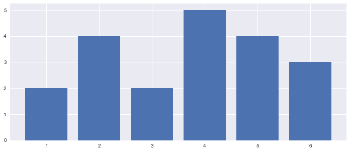

```python
plt.figure(figsize=(12,5))

# axis=0 ↓로 연산
plt.bar(np.arange(1, 7), X.sum(axis=0), align="center")
plt.show()
```

```python
df = pd.DataFrame({"theoretic": theta, "simulation": X.mean(axis=0)})
df
```

|  | simulation | theoretic |
| --- | --- | --- |
| 0 | 0.10 | 0.166667 |
| 1 | 0.20 | 0.166667 |
| 2 | 0.10 | 0.166667 |
| 3 | 0.25 | 0.166667 |
| 4 | 0.20 | 0.166667 |
| 5 | 0.15 | 0.166667 |

```python
df.stack()
```

```
0  simulation    0.100000
   theoretic     0.166667
1  simulation    0.200000
   theoretic     0.166667
2  simulation    0.100000
   theoretic     0.166667
3  simulation    0.250000
   theoretic     0.166667
4  simulation    0.200000
   theoretic     0.166667
5  simulation    0.150000
   theoretic     0.166667
dtype: float64
```

```python
df_1 = df.stack().reset_index()
df_1.columns = ["value", "type", "ratio"]
df_1.head()
```

|  | value | type | ratio |
| --- | --- | --- | --- |
| 0 | 0 | simulation | 0.100000 |
| 1 | 0 | theoretic | 0.166667 |
| 2 | 1 | simulation | 0.200000 |
| 3 | 1 | theoretic | 0.166667 |
| 4 | 2 | simulation | 0.100000 |

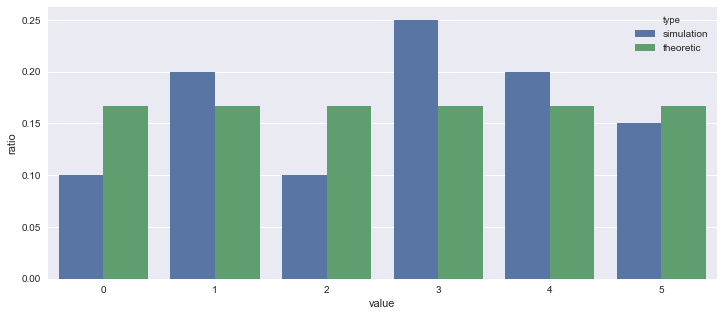

```python
plt.figure(figsize=(12,5))

sns.barplot(x="value", y="ratio", hue="type", data=df_1)
plt.show()
```

*theta*를 다른 값으로 실행해보자

```python
np.random.seed(0)
theta = np.array([0, 0, 0.1, 0.2, 0.3, 0.4])
X = np.random.multinomial(1, theta, size=20)
X[:8]
```

```
array([[0, 0, 0, 0, 0, 1],
       [0, 0, 0, 1, 0, 0],
       [0, 0, 0, 0, 1, 0],
       [0, 0, 0, 1, 0, 0],
       [0, 0, 1, 0, 0, 0],
       [0, 0, 0, 0, 1, 0],
       [0, 0, 0, 0, 0, 1],
       [0, 0, 0, 0, 1, 0]])
```

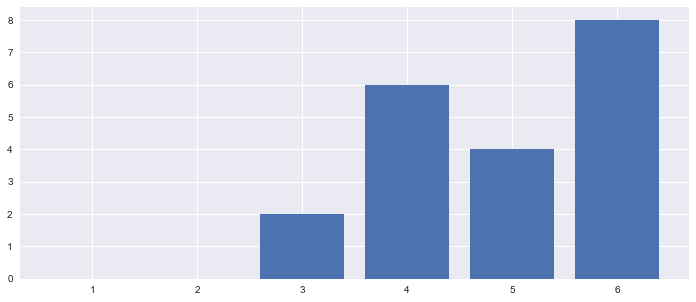

```python
plt.figure(figsize=(12,5))

plt.bar(np.arange(1, 7), X.sum(axis=0), align="center")
plt.show()
```

```python
df = pd.DataFrame({"theoretic": theta, "simulation": X.mean(axis=0)}).stack()
df = df.reset_index()
df.columns = ["value", "type", "ratio"]
df.head()
```

|  | value | type | ratio |
| --- | --- | --- | --- |
| 0 | 0 | simulation | 0.0 |
| 1 | 0 | theoretic | 0.0 |
| 2 | 1 | simulation | 0.0 |
| 3 | 1 | theoretic | 0.0 |
| 4 | 2 | simulation | 0.1 |

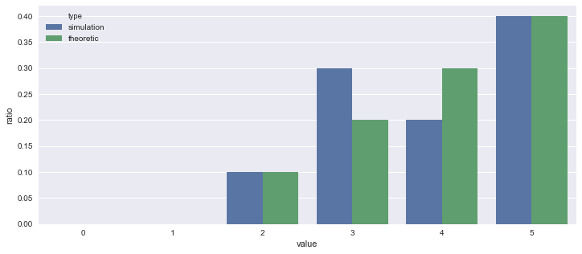

```python
plt.figure(figsize=(12,5))
sns.barplot(x="value", y="ratio", hue="type", data=df)
plt.show()
```

### Multinomial distribution(다항 분포)

> 베르누이 n번 독립 시행 → 총 성공 횟수 합 ~ 이항 분포

> **카테고리 분포 n번 독립 시행 → 얻은 각 원소의 성공 횟수 값 ~ 다항 분포(Multinomial distribution)**

> > 카테고리 분포(단일 변수) → 다량 변수로 확장했다고 생각해도 된다.

> 정의1.

> > 여러 개의 값을 갖을 수 있는 독립확률변수들에 대한 확률 분포

> > 여러 번의 독립적 시행에서 각각의 값이 특정 횟수가 나타날 확률 변수이다.

> 정의2.

> > 어떤 시행에서 k가지의 값이 나타날 수 있고, 그 값들이 나타날 확률을 각각 P_1, P_2, P_3, ..., P_k라고 할 때,

> > n번의 시행에서 i 번째 값이 x_i회 나타날 확률이다.

$$ \begin{eqnarray} P(x_1, x_2, \cdots, x_k ; n, \;p_1, \cdots, p_k) &=& \frac{n!}{x_1!\cdot x_2!\cdots x_k!}\;p_1^{x_1}\cdots p_k^{x_k} \;\;\;(단,\;\; x_1+\cdots+x_k = n,\;\;\; p_1 + \cdots + p_k = 1) \\ \\&=& \binom n {x_1, \cdots, x_k} \prod_{i=1}^k \;p_i^{x_i} \\ \\&=& \binom n X \prod_{i=1}^k \;p_i^{x_i}\\ \\&=& \text{Mu}(X;n,P) \end{eqnarray} $$

> Multinomail distribution의 개념을 정리해보면

$$ 확률\;\;\theta = (\theta_1, \cdots, \theta_K)인\;\; 카테고리 \;\;시도를\;\; N번\;\; 반복해서\;\; k가\;\; 각각 \;\;x_k번\;\; 나올\;\; 확률,\;\;즉,\;\; 벡터 X = (x_1, \cdots, x_K)가\;\; 나올 \;확률이다. $$

$$ \text{Mu}(X;N,\theta) = \binom N X \prod_{i=1}^K \theta_i^{x_i} = \binom N {x_1, \cdots, x_K} \prod_{i=1}^K \theta_i^{x_i} $$$$ \binom N {x_1, \cdots, x_K} = \dfrac{N!}{x_1! \cdots x_K!} $$

> mean

$$E[x_k] = N\theta_k$$

> variance:

$$\text{Var}[x_k] = N\theta_k(1-\theta_k)$$

#### 카테고리 분포와 마찬가지로 위의 값들은 벡터의 기대값들이다.

### 시뮬레이션

```python
np.random.seed(0)
N = 30
theta = np.array([0, 0, 0.1, 0.2, 0.3, 0.4])

# 다항분포는 n = N
X = np.random.multinomial(N, theta, size=100)
X[:5]
```

```
array([[ 0,  0,  3,  6,  9, 12],
       [ 0,  0,  5,  9,  6, 10],
       [ 0,  0,  3,  9,  5, 13],
       [ 0,  0,  5,  7, 10,  8],
       [ 0,  0,  3,  8,  6, 13]])
```

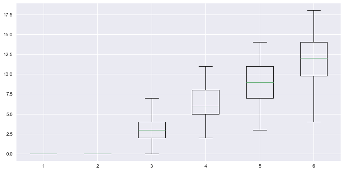

```python
plt.figure(figsize=(12,6))
plt.boxplot(X)
plt.show()
```

```python
pd.DataFrame(X).head()
```

|  | 0 | 1 | 2 | 3 | 4 | 5 |
| --- | --- | --- | --- | --- | --- | --- |
| 0 | 0 | 0 | 3 | 6 | 9 | 12 |
| 1 | 0 | 0 | 5 | 9 | 6 | 10 |
| 2 | 0 | 0 | 3 | 9 | 5 | 13 |
| 3 | 0 | 0 | 5 | 7 | 10 | 8 |
| 4 | 0 | 0 | 3 | 8 | 6 | 13 |

```python
df = pd.DataFrame(X).stack().reset_index()
df.columns = ["trial", "class", "binomial"]
df.head()
```

|  | trial | class | binomial |
| --- | --- | --- | --- |
| 0 | 0 | 0 | 0 |
| 1 | 0 | 1 | 0 |
| 2 | 0 | 2 | 3 |
| 3 | 0 | 3 | 6 |
| 4 | 0 | 4 | 9 |

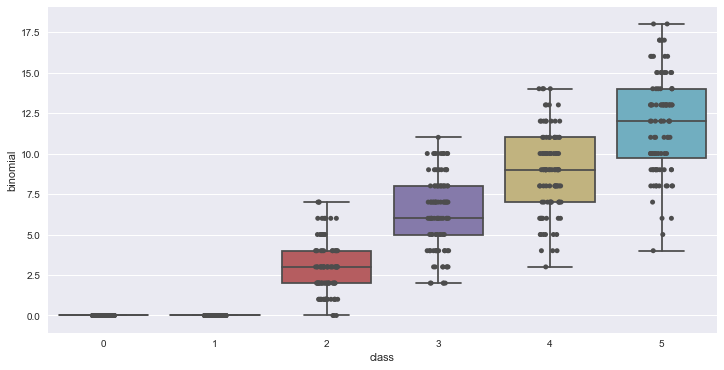

```python
plt.figure(figsize=(12,6))
sns.boxplot(x="class", y="binomial", data=df)
sns.stripplot(x="class", y="binomial", data=df, jitter=True, color=".3")
plt.show()
```

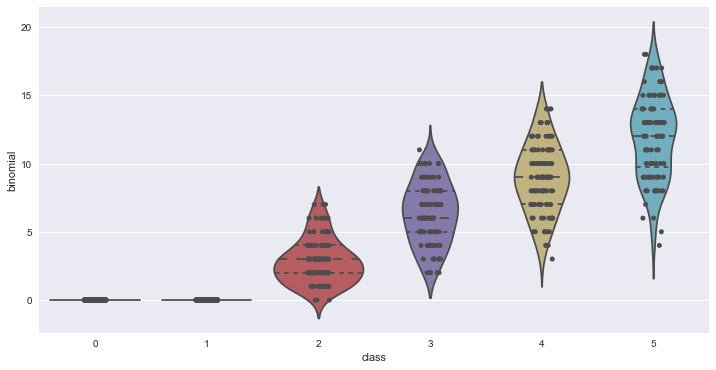

```python
plt.figure(figsize=(12,6))
sns.violinplot(x="class", y="binomial", data=df, inner="quartile")
sns.stripplot(x="class", y="binomial", data=df, jitter=True, color=".3")
plt.show()
```

> Share this on → [Tweet](https://twitter.com/share)

#### Related Posts

- [모수 추정 ③ (베이지안 모수 추정 MAP)](http://localhost:4000/statistics/2017/09/18/probability/) (Categories: statistics)
- [모수 추정 ② (MLE 계산)](http://localhost:4000/statistics/2017/09/17/probability/) (Categories: statistics)
- [모수 추정 ① (MM, MLE)](http://localhost:4000/statistics/2017/09/15/probability/) (Categories: statistics)
- [가설과 검정 ③](http://localhost:4000/statistics/2017/09/14/probability/) (Categories: statistics)
- [가설과 검정 ②](http://localhost:4000/statistics/2017/09/13/probability_1/) (Categories: statistics)
- [가설과 검정 ①](http://localhost:4000/statistics/2017/09/13/probability/) (Categories: statistics)

> « Python basic (객체지향 프로그래밍 ①) 디리클레 분포 »